# Predictive modeling for cancer prognosis

Andrew Gentles

7/19/2018

# About this activity

This module will introduce you to loading and manipulating the data from the breast cancer METABRIC dataset, visualizing and working with **gene expression** measurements, and building predictive models based on the expression of many different genes (and clinical data too).

The METABRIC dataset is from another large breast cancer patient study and was actually used for the original DREAM Breast Cancer Prognosis Challenge. After taking an initial look at modeling survival in the TCGA BRCA cohort, we realized there wasn’t much interesting to see. This is a useful lesson in making sure you have the right data for the analysis! In a [study](https://www.ncbi.nlm.nih.gov/pubmed/29625055) published earlier this year, a group of researchers carefully assessed which clinical outcomes can be reliably used for modeling across TCGA cancer types — this study also produced the **TCGA Pan-Cancer Clinical Data Resource (CDR)** dataset that we’ve seen in a couple modules.

For now, we’ve switched to the METABRIC study, where we know from previous experience there are at least some strong relationships between gene expression and survival.

# Loading & inspecting data

Let’s load the data — both the expression matrix and a table of clinical information. They are saved conveniently in files of type .RData as with previous modules. These are binary files (i.e., not human readable) that store multiple R objects (results) that you create in the process of an R analysis. We’ll load the datasets, and list what we loaded with the `ls()` command,

```r
load(file.path(data_dir, "metabric_disc_expr_df.RData"))
load(file.path(data_dir, "metabric_disc_clin_df.RData"))
load(file.path(data_dir, "metabric_expr_gene_info.RData"))
ls()
```

```
 [1] "create_module0_submission" "create_module1_submission" "create_module2_submission" "create_module3_submission"
 [5] "create_module4_submission" "data_dir"                  "gene_df"                   "metabric_disc_clin_df"
 [9] "metabric_disc_expr_df"     "scripts_dir"               "set_basepath"              "submit_module_answers"
```

The clinical data frame is a bit unwieldy — we can use **`View()`** to take a look. In RStudio, you can also click on the variable under the **Environment** tab in the upper right panel. **Reminder:** running the chunk below will open the viewer in a new tab; you can switch back to this tab to resume the activity.

```r
# remove the '#' before View before running
View(metabric_disc_clin_df)
```

Reminder: We can find the dimensions of a matrix or data frame with the `dim()` command, to see just how large the expression data matrix is…

```r
dim(metabric_disc_clin_df)
```

```
[1] 997  32
```

```r
dim(metabric_disc_expr_df)
```

```
[1] 15834   999
```

Each row of the clinical data frame is one patient, and each column of the expression data frame is for one patient (except for the first two, which store the gene information for each row). Let’s check whether they’re both in the same order:

```r
metabric_disc_clin_df$metabric_id[1:10]
```

```
 [1] "MB_0362" "MB_0346" "MB_0386" "MB_0574" "MB_0185" "MB_0503" "MB_0641" "MB_0201" "MB_0218" "MB_0316"
```

```r
names(metabric_disc_expr_df)[3:12]
```

```
 [1] "MB_0362" "MB_0346" "MB_0386" "MB_0574" "MB_0185" "MB_0503" "MB_0641" "MB_0201" "MB_0218" "MB_0316"
```

Let’s convert the expression data frame into a matrix for more convenient use below:

```r
metabric_disc_expr_mat <- as.matrix(metabric_disc_expr_df[, -c(1:2)])
rownames(metabric_disc_expr_mat) <- metabric_disc_expr_df$symbol
metabric_disc_expr_mat[1:5, 1:5]
```

```
         MB_0362 MB_0346 MB_0386 MB_0574 MB_0185
TSPAN6     7.579   7.819   7.366   8.110   5.993
TNMD       6.211   5.557   8.108   5.789   5.484
DPM1       9.150   9.794   9.229   9.672  10.159
SCYL3      7.193   7.845   6.777   6.863   6.692
C1orf112   7.835   8.084   6.895   6.987   7.173
```

And it never hurts to do yet another check to make sure nothing went astray… The `match()` function tells us the position in the 2nd vector where each element in the 1st vector can be found — ideally, we want these numbers to be increasing from 1 to the length of the vector.

```r
dim(metabric_disc_clin_df)
```

```
[1] 997  32
```

```r
dim(metabric_disc_expr_mat)
```

```
[1] 15834   997
```

```r
match(metabric_disc_clin_df$metabric_id, colnames(metabric_disc_expr_mat))
```

```
  [1]   1   2   3   4   5   6   7   8   9  10  11  12  13  14  15  16  17  18  19  20  21  22  23  24  25  26  27  28  29  30  31
 [32]  32  33  34  35  36  37  38  39  40  41  42  43  44  45  46  47  48  49  50  51  52  53  54  55  56  57  58  59  60  61  62
 [63]  63  64  65  66  67  68  69  70  71  72  73  74  75  76  77  78  79  80  81  82  83  84  85  86  87  88  89  90  91  92  93
 [94]  94  95  96  97  98  99 100 101 102 103 104 105 106 107 108 109 110 111 112 113 114 115 116 117 118 119 120 121 122 123 124
[125] 125 126 127 128 129 130 131 132 133 134 135 136 137 138 139 140 141 142 143 144 145 146 147 148 149 150 151 152 153 154 155
[156] 156 157 158 159 160 161 162 163 164 165 166 167 168 169 170 171 172 173 174 175 176 177 178 179 180 181 182 183 184 185 186
[187] 187 188 189 190 191 192 193 194 195 196 197 198 199 200 201 202 203 204 205 206 207 208 209 210 211 212 213 214 215 216 217
[218] 218 219 220 221 222 223 224 225 226 227 228 229 230 231 232 233 234 235 236 237 238 239 240 241 242 243 244 245 246 247 248
[249] 249 250 251 252 253 254 255 256 257 258 259 260 261 262 263 264 265 266 267 268 269 270 271 272 273 274 275 276 277 278 279
[280] 280 281 282 283 284 285 286 287 288 289 290 291 292 293 294 295 296 297 298 299 300 301 302 303 304 305 306 307 308 309 310
[311] 311 312 313 314 315 316 317 318 319 320 321 322 323 324 325 326 327 328 329 330 331 332 333 334 335 336 337 338 339 340 341
[342] 342 343 344 345 346 347 348 349 350 351 352 353 354 355 356 357 358 359 360 361 362 363 364 365 366 367 368 369 370 371 372
[373] 373 374 375 376 377 378 379 380 381 382 383 384 385 386 387 388 389 390 391 392 393 394 395 396 397 398 399 400 401 402 403
[404] 404 405 406 407 408 409 410 411 412 413 414 415 416 417 418 419 420 421 422 423 424 425 426 427 428 429 430 431 432 433 434
[435] 435 436 437 438 439 440 441 442 443 444 445 446 447 448 449 450 451 452 453 454 455 456 457 458 459 460 461 462 463 464 465
```

[output cut: 18 more lines]

Now we are ready to do some actual analysis!

# Exploring AURKA expression & survival

We happen to know that high AURKA expression in a tumor is bad for the patient’s outcome (https://doi.org/10.1093/bioinformatics/btn374). AURKA (Aurora kinase A) encodes for a protein that is involved in regulation of progression through the cell cycle. Various studies have associated it with tumour progression and it is thought to promote metastasis.

```r
aurka_row <- which(rownames(metabric_disc_expr_mat) == "AURKA")
aurka_row
```

```
[1] 1595
```

```r
aurka <- as.vector(metabric_disc_expr_mat[aurka_row, ])
aurka
```

```
  [1]  7.918  9.626  7.689  7.738  8.612  7.083  6.769  8.211  9.697  8.645  7.236  6.220  8.678  7.500  6.362  7.416 11.767  8.489
 [19]  7.208  7.195  6.991  6.999  6.183  8.220  7.532  7.805  8.173  8.831  9.731  9.217  7.931  7.292  8.078  8.921  8.413  6.577
 [37]  7.508  8.768  7.927  7.248  8.261  7.996  6.849  6.447  9.380  7.629  7.582  7.513  8.531  8.504  7.322  7.463  7.327  8.126
 [55]  8.458  8.017  6.488  7.279  6.128  8.181  8.798  8.298  6.832  7.483  8.571  7.051  7.034  8.094  7.682  8.161  7.373  6.288
 [73]  7.674  9.401  8.819  8.004  8.109  8.135  7.326  6.571  7.821  7.452  7.673  7.032  8.271  7.472  7.601  8.142  8.633  8.927
 [91]  6.741  7.034  8.316  8.535  6.398  8.767  7.202  7.387  6.149  6.541  7.004  6.772  6.987  6.813  6.991  8.085  8.524  7.624
[109]  7.654  8.229  8.579  7.956  6.297  7.766  7.106  7.713  7.362  7.379  6.887  9.270  6.835  8.536  9.452  8.239  7.520  8.107
[127]  7.526  6.154  8.748  7.736  8.569  6.872  7.380  6.284  7.682  6.685  7.819  7.259  7.049  7.535  7.816  7.460  7.939  6.848
[145]  7.358  8.048  7.018  6.811  7.287  7.010  6.586  6.893  7.499  9.333  6.885  7.459  8.979  8.110  8.185  7.439  7.443  7.088
[163]  8.794  7.043  8.730  8.356  8.738  6.605  6.705  6.816  6.942  6.716  6.787  6.428  6.875  6.308  7.696  7.203  6.252  6.343
[181]  7.802  8.326  8.258  8.730  8.498  6.928  7.563  7.420  8.522  6.872  7.641  7.136  7.496  8.314  8.716  8.062  7.782  8.211
[199]  7.339  8.122  7.869  8.917  6.829  6.803  8.896  8.157  8.155  6.467  6.304  6.908  9.061  7.224  7.765  8.716  6.209  6.250
[217]  7.295  7.729  8.682  7.500  8.218  7.961  6.890  6.331  7.061  9.111  7.980  8.426  8.629  6.129  6.534  8.001  7.599  7.588
[235]  9.349  6.383  6.823  7.657  6.830  8.270  7.979  7.496  6.664  7.052  7.019  7.053  7.901  7.755  6.230  8.789  8.265  8.626
[253]  9.110  6.902  8.915  6.154  6.749  8.854  7.074  8.479  7.723  7.476  8.848  7.906  6.400  7.046  7.284  7.670  8.161  6.594
```

[output cut: 41 more lines]

How is the expression of AURKA related to being alive at 5 years? Here are a few different ways to look at the relationship.

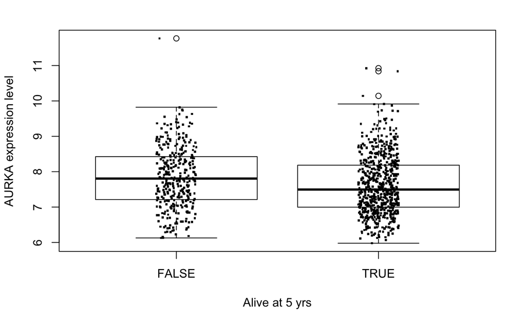

```r
boxplot(aurka ~ metabric_disc_clin_df$survival_5y,
        xlab = "Alive at 5 yrs", ylab = "AURKA expression level")
stripchart(aurka ~ metabric_disc_clin_df$survival_5y,
           vertical = TRUE, method = "jitter", pch = '.', cex = 3, add = TRUE)
```

```r
summary(lm(aurka ~ metabric_disc_clin_df$survival_5y))
```

```
Call:
lm(formula = aurka ~ metabric_disc_clin_df$survival_5y)

Residuals:
    Min      1Q  Median      3Q     Max
-1.7165 -0.6235 -0.1070  0.5700  3.9225

Coefficients:
                                      Estimate Std. Error t value Pr(>|t|)
(Intercept)                            7.84454    0.04539 172.813  < 2e-16 ***
metabric_disc_clin_df$survival_5yTRUE -0.22350    0.05595  -3.995 6.95e-05 ***
---
Signif. codes:  0 ‘***’ 0.001 ‘**’ 0.01 ‘*’ 0.05 ‘.’ 0.1 ‘ ’ 1

Residual standard error: 0.837 on 993 degrees of freedom
  (2 observations deleted due to missingness)
Multiple R-squared:  0.01582,   Adjusted R-squared:  0.01483
F-statistic: 15.96 on 1 and 993 DF,  p-value: 6.952e-05
```

## Removing censored patients

Another way of looking at things is to just take the patients who *died of disease*, and to look at how long it was before that occurred. To do that, we’ll want to exclude the rows and columns for patients who alive at the last time they were followed *OR* who died of other causes. These patients are known as “censored” events.

```r
table(metabric_disc_clin_df$last_follow_up_status)
```

```
     a      d d-d.s. d-o.c.
   548     46    259    126
```

Rather than filtering out patients with `last_follow_up_status` equal to `a` or `d-o.c.`, we can actually use the `censored` column in the data frame. You’ll see that the number of censored patients (674) is equal to the total of alive (548) and died of other causes (126) patients.

```r
table(metabric_disc_clin_df$censored)
```

```
FALSE  TRUE
  323   674
```

So, now we’ll drop the censored patients from the data.

```r
drop_pats <- which(metabric_disc_clin_df$censored)
dead_clin <- metabric_disc_clin_df[-drop_pats, ]
dead_expr <- metabric_disc_expr_mat[, -drop_pats]
dim(dead_clin)
```

```
[1] 323  32
```

```r
dim(dead_expr)
```

```
[1] 15834   323
```

That’s less than half of patients in total — though note that only 259 were specifically indicated to have died from breast cancer; the 46 patients labelled as `d` we *think* died of cancer, but the cause for these patients could be unknown. This is often a problem — the unknown or “other cause”" might have been something completely unrelated, or something that was indirectly caused by having cancer, so we usually want to be careful about how we treat these cases.

## Modeling survival and AURKA expression

Let’s see how the expression level of AURKA is related to time-to-death with a plot that includes a trend line representing the linear model from `lm()`.

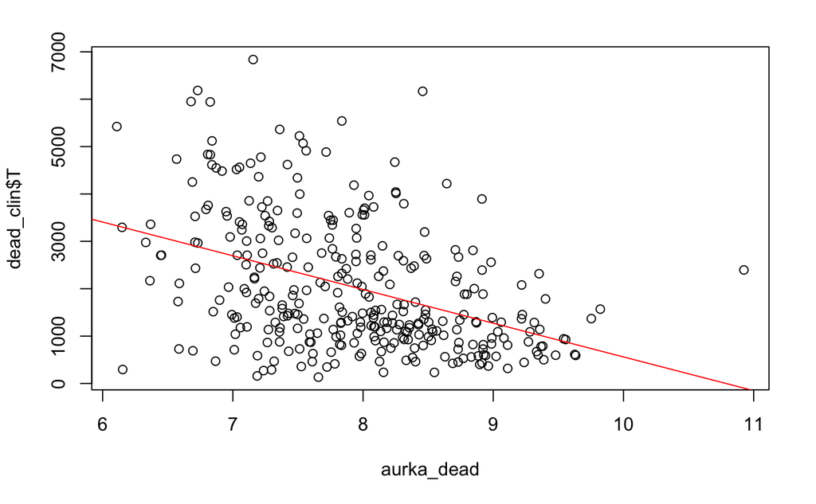

```r
# make sure to remove censored patients from the `aurka` vector
aurka_dead = aurka[-drop_pats]
plot(dead_clin$T ~ aurka_dead )
aurka_model <- lm(dead_clin$T ~ aurka_dead)
abline(aurka_model, col = "red")
```

There are several things in the output of `lm()` that might be interesting, and the `summary()` of it has even more detail, such as p-values. Here we store it as an object and then see what it includes.

```r
aurka_model_summary <- summary(aurka_model)
aurka_model_summary
```

```
Call:
lm(formula = dead_clin$T ~ aurka_dead)

Residuals:
    Min      1Q  Median      3Q     Max
-3003.3  -844.4  -256.2   773.7  4508.6

Coefficients:
            Estimate Std. Error t value Pr(>|t|)
(Intercept)  7678.72     695.86  11.035  < 2e-16 ***
aurka_dead   -711.79      87.35  -8.149 8.43e-15 ***
---
Signif. codes:  0 ‘***’ 0.001 ‘**’ 0.01 ‘*’ 0.05 ‘.’ 0.1 ‘ ’ 1

Residual standard error: 1250 on 319 degrees of freedom
  (2 observations deleted due to missingness)
Multiple R-squared:  0.1723,    Adjusted R-squared:  0.1697
F-statistic: 66.41 on 1 and 319 DF,  p-value: 8.426e-15
```

Specifically, we can pull out the estimate (slope) for how AURKA is associated with time to death, and the p-value.

```r
coef_aurka_model = coefficients(aurka_model_summary)
slope = coef_aurka_model[2, 1]
pval = coef_aurka_model[2, 4]
slope
```

```
[1] -711.7943
```

```r
pval
```

```
[1] 8.426028e-15
```

## Including clinical variables with expression

### Continuous variables

The number of lymph nodes found to be positive for cancer cells at the time of diagnosis can also be a strong predictor of time until the person dies. We would probably want to allow for these variables like these in a survival model.

There are many ways to include multiple variables in a model — one would be to fit the time to death as a function of both positive lymph node coudnt and other variables (e.g., AURKA expression). We can do this easily for the combination of positive lymph nodes and AURKA with `lm()`.

```r
summary(lm(dead_clin$T ~ dead_clin$lymph_nodes_positive + aurka_dead))
```

```
Call:
lm(formula = dead_clin$T ~ dead_clin$lymph_nodes_positive + aurka_dead)

Residuals:
    Min      1Q  Median      3Q     Max
-2400.1  -857.5  -179.4   679.9  4308.6

Coefficients:
                               Estimate Std. Error t value Pr(>|t|)
(Intercept)                     7599.93     676.37  11.236  < 2e-16 ***
dead_clin$lymph_nodes_positive   -62.72      14.07  -4.459 1.14e-05 ***
aurka_dead                      -678.83      85.19  -7.968 2.90e-14 ***
---
Signif. codes:  0 ‘***’ 0.001 ‘**’ 0.01 ‘*’ 0.05 ‘.’ 0.1 ‘ ’ 1

Residual standard error: 1214 on 318 degrees of freedom
  (2 observations deleted due to missingness)
Multiple R-squared:  0.221, Adjusted R-squared:  0.2161
F-statistic: 45.11 on 2 and 318 DF,  p-value: < 2.2e-16
```

By “controlling” for survival differences related to positive lymph nodes, we’re able to focus our model on differences that might be more specifically related to AURKA expression. If, alternatively, we included `lymph_nodes_positive` and the effect of `aurka_dead` disappeared, we might deduce that these variables were *confounded* in some way.

### Categorical variables

We’ve also learned about how ER expression status can be an indicator of survival. In this case, we have to “categories” among our patients: “positive” for ER (`+`) and “negative” for ER (`-`).

```r
table(dead_clin$ER.Expr)
```

```
  -   +
 91 230
```

```r
summary(lm(dead_clin$T ~ dead_clin$ER.Expr + aurka_dead))
```

```
Call:
lm(formula = dead_clin$T ~ dead_clin$ER.Expr + aurka_dead)

Residuals:
    Min      1Q  Median      3Q     Max
-2498.6  -808.0  -203.8   674.1  4241.8

Coefficients:
                   Estimate Std. Error t value Pr(>|t|)
(Intercept)         6111.53     770.71   7.930 3.76e-14 ***
dead_clin$ER.Expr+   687.18     160.87   4.272 2.57e-05 ***
aurka_dead          -576.20      90.81  -6.345 7.63e-10 ***
---
Signif. codes:  0 ‘***’ 0.001 ‘**’ 0.01 ‘*’ 0.05 ‘.’ 0.1 ‘ ’ 1

Residual standard error: 1217 on 318 degrees of freedom
  (2 observations deleted due to missingness)
Multiple R-squared:  0.2172,    Adjusted R-squared:  0.2123
F-statistic: 44.12 on 2 and 318 DF,  p-value: < 2.2e-16
```

Your first observation here might be: “what happened to ER `-`?” When given categorical variables, R will treat one of the values as the intercept for the line it fits. We can therefore interpret the remaining coefficient `ER.Expr+` as “the change in survival time when ER status changes from `-` to `+`”. As we might expect, patients who are ER+ are predicted to survive longer.

### Categorical variables …?

How about another common clinical variable, such as tumor “grade”?

```r
table(dead_clin$grade)
```

```
  1   2   3
 15 107 199
```

Including grade with AURKA expression would look like this:

```r
summary(lm(dead_clin$T ~ dead_clin$grade + aurka_dead))
```

```
Call:
lm(formula = dead_clin$T ~ dead_clin$grade + aurka_dead)

Residuals:
    Min      1Q  Median      3Q     Max
-2711.3  -829.8  -269.3   703.7  4610.4

Coefficients:
                Estimate Std. Error t value Pr(>|t|)
(Intercept)      7725.19     687.70  11.233  < 2e-16 ***
dead_clin$grade  -388.02     130.92  -2.964  0.00327 **
aurka_dead       -591.69      95.34  -6.206 1.69e-09 ***
---
Signif. codes:  0 ‘***’ 0.001 ‘**’ 0.01 ‘*’ 0.05 ‘.’ 0.1 ‘ ’ 1

Residual standard error: 1235 on 318 degrees of freedom
  (2 observations deleted due to missingness)
Multiple R-squared:  0.1946,    Adjusted R-squared:  0.1895
F-statistic: 38.41 on 2 and 318 DF,  p-value: 1.147e-15
```

We see that increasing grade has a negative relationship with survival time (as we might expect), and that relationship is significant — great! But wait… something is funny about how `lm()` treated the `grade` variable. Can you tell what’s wrong? Think about how the model looked when we considered the number of positive lymph nodes compared to ER status.

> Cue Jeopardy music…

The problem here is that R doesn’t know grade numbers (1, 2, 3) represent different categories, so it just treats them as continuous values. Let’s see what that looks like with a plot of time versus grade.

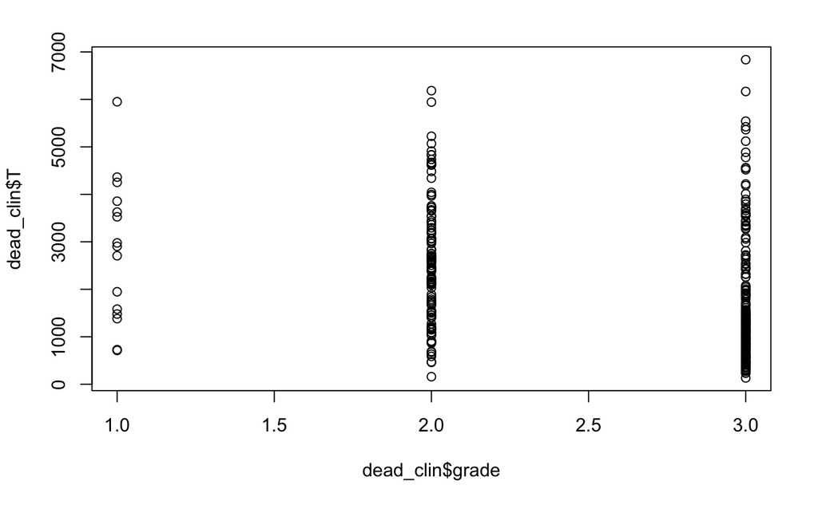

```r
plot(dead_clin$T ~ dead_clin$grade)
```

What we need to do is convert the `grade` variable into a **`factor`** — this tells R to treat each “level” of the factor as a distinct category. Try the plot now.

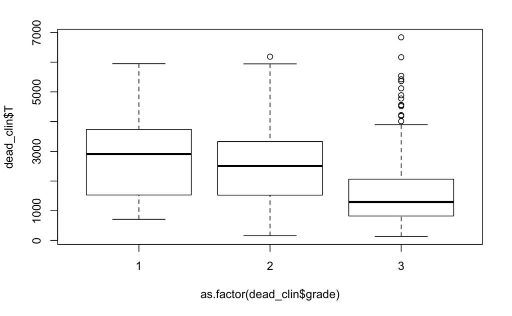

```r
plot(dead_clin$T ~ as.factor(dead_clin$grade))
```

Better! How does our model look?

```r
summary(lm(dead_clin$T ~ as.factor(dead_clin$grade) + aurka_dead))
```

```
Call:
lm(formula = dead_clin$T ~ as.factor(dead_clin$grade) + aurka_dead)

Residuals:
    Min      1Q  Median      3Q     Max
-2642.2  -818.3  -238.0   655.5  4638.3

Coefficients:
                            Estimate Std. Error t value Pr(>|t|)
(Intercept)                  6951.95     741.12   9.380  < 2e-16 ***
as.factor(dead_clin$grade)2    91.47     343.70   0.266    0.790
as.factor(dead_clin$grade)3  -430.85     347.36  -1.240    0.216
aurka_dead                   -590.26      95.15  -6.203 1.73e-09 ***
---
Signif. codes:  0 ‘***’ 0.001 ‘**’ 0.01 ‘*’ 0.05 ‘.’ 0.1 ‘ ’ 1

Residual standard error: 1232 on 317 degrees of freedom
  (2 observations deleted due to missingness)
Multiple R-squared:  0.2003,    Adjusted R-squared:  0.1927
F-statistic: 26.47 on 3 and 317 DF,  p-value: 2.655e-15
```

We won’t actually include grade in our models below. Long story short, interpreting the relationship between survival time and tumor grade (at least for this set of patients) is a bit confusing.

# Modeling survival for all genes

Putting all these bits together, we can write a function that takes the time to death (y below) does a fit to some variable x, such as the expression of AURKA, and extracts the slope (direction of the association) and statistical significance.

```r
# Do a linear fit of y ~ x and return the slope and p-value
gene_lm <- function(y, x) {
    gene_model_summary <- NULL
    pval <- NA
    slope <- NA
    try(gene_model_summary <- summary(lm(y ~ x)))
    if (!is.null(gene_model_summary)) {
        coef_gene_model <- coefficients(gene_model_summary)
        pval = coef_gene_model[2, 4]
        slope = coef_gene_model[2, 1]
    }
    return(c(pval, slope))
}
```

Check this got the same as we had before.

```r
gene_lm(dead_clin$T, aurka_dead)
```

```
[1]  8.426028e-15 -7.117943e+02
```

Note that these models aren’t including any information about stage or grade.

```r
# If we were doing all genes, `ngenes` would be nrow(dead_expr), i.e. the number of rows of genes
ngenes <- 5000
lm_results = matrix(nrow = ngenes, ncol = 2, data = NA)
colnames(lm_results) <- c("pval", "slope")
rownames(lm_results) <- rownames(dead_expr)[1:ngenes]
for (i in 1:ngenes) {
    lm_results[i, ] <- gene_lm(dead_clin$T, dead_expr[i,])
}
```

And we check on AURKA again.

```r
lm_results[rownames(lm_results) == "AURKA", ]
```

```
         pval         slope
 8.426028e-15 -7.117943e+02
```

```r
lm_results = lm_results[order(lm_results[, 1]), ]
# output as a data frame so that R Notebook formats the table nicely
as.data.frame(lm_results)
```

|  | pval | slope |
| --- | --- | --- |
| AVP | 5.637819e-18 | 1678.96544 |
| CENPA | 1.130745e-16 | -855.04537 |
| ANLN | 7.649051e-16 | -995.27729 |
| RABEP1 | 2.573654e-15 | 627.63368 |
| AURKA | 8.426028e-15 | -711.79427 |
| FAM83D | 4.566357e-14 | -733.20900 |
| MCM10 | 7.459059e-14 | -751.76699 |
| TRIP13 | 9.654274e-14 | -710.34865 |
| STMN1 | 4.681205e-13 | -807.27260 |
| SEC14L2 | 7.382927e-13 | 501.61811 |

[output cut: 990 more lines]

# mini-DREAM Challenge

**QUESTION:** How well can we predict survival based on the expression of a single gene?

Now that you’ve built a model to predict survival time based on gene expression, we can apply it to the samples in a new dataset and submit our predictions to the **mini-DREAM Challenge**.

First, load the challenge validation data:

```r
load(file.path(data_dir, "metabric_val_expr_df.RData"), verbose = TRUE)
```

```
Loading objects:
  metabric_val_expr_df
```

```r
load(file.path(data_dir, "metabric_val_masked_clin_df.RData"), verbose = TRUE)
```

```
Loading objects:
  metabric_val_masked_clin_df
```

This is a *distinct* set of samples from the ones we were looking at above. If you notice the word “masked” in the variable name of the clinical data frame, that’s because we’ve “hidden” the survival time for these patients. You’ll train a model based on *other* variables in the dataset (expression or clinical) and then find out how well your prediction matched the real answer.

## Formatting the challenge data

Once again, double check that our sample IDs are in the same order:

```r
metabric_val_masked_clin_df$metabric_id[1:10]
```

```
 [1] "MB_0005" "MB_0048" "MB_0025" "MB_0083" "MB_0053" "MB_0056" "MB_0068" "MB_0093" "MB_0079" "MB_0108"
```

```r
names(metabric_val_expr_df)[3:12]
```

```
 [1] "MB_0005" "MB_0048" "MB_0025" "MB_0083" "MB_0053" "MB_0056" "MB_0068" "MB_0093" "MB_0079" "MB_0108"
```

```r
metabric_val_expr_mat <- as.matrix(metabric_val_expr_df[, -c(1:2)])
rownames(metabric_val_expr_mat) <- metabric_val_expr_df$symbol
metabric_val_masked_clin_df[1:5,1:5]
```

| metabric_id | last_follow_up_status | OS_Status | age_at_diagnosis | size |
| --- | --- | --- | --- | --- |
| MB_0005 | a | 0 | 48.87 | 15 |
| MB_0048 | a | 0 | 51.46 | 25 |
| MB_0025 | a | 0 | 76.24 | 34 |
| MB_0083 | d-d.s. | 1 | 64.85 | 13 |
| MB_0053 | a | 0 | 70.02 | 23 |

```r
metabric_val_expr_mat[1:5,1:5]
```

```
         MB_0005 MB_0048 MB_0025 MB_0083 MB_0053
TSPAN6     8.897   8.366   8.049   9.539   6.787
TNMD       5.687   6.547   6.039   6.455   6.175
DPM1      10.565  10.926  11.172  11.229  12.616
SCYL3      8.458   8.684   8.598   8.692   7.981
C1orf112   7.115   6.807   7.399   7.622   6.738
```

Because we only aim to predict survival time for those patients who ultimately die, we must also remove censored samples (the patients who did not die during followup) from both the clinical table rows, and the expression data columns.

```r
chal_drop_pats <- which(metabric_val_masked_clin_df$censored)
chal_dead_clin <- metabric_val_masked_clin_df[-drop_pats, ]
chal_dead_expr <- metabric_val_expr_mat[, -drop_pats]
dim(chal_dead_clin)
```

```
[1] 323  30
```

```r
dim(chal_dead_expr)
```

```
[1] 15834   323
```

## Training our model

Now we’ll add gene expression into our data frames with clinical variables — this makes it easier for us to train and apply our model with the same syntax. **AVP** came out with the most significant p-value, and it seems to have a beneficial effect on outcome — the higher it is, the longer patients survive. The following will select it as the final model to submit. You might want to pick a different one so that we see a variety of different genes in the validation step.

> This is where you can change to a different gene if you want to pick something else out of the top ranked ones from the discovery part above!

> Hint: there’s no guarantee that the top gene from the training data will also be the best predictor for the challenge samples!

> Since metastasis is a major driver of survival, it would be interesting to see if some of the genes that you identified from looking at PS-ON in Module 1 are important. Check out the [Module 1 scoreboards](https://www.synapse.org/#!Synapse:syn12105406/wiki/566100) for some other gene ideas to try.

```r
# pick the gene to use in your model here!
my_model_gene <- "AVP"
# add gene expression to the training clinical table above
gene_exp <- as.vector(dead_expr[my_model_gene, ])
dead_clin$gene_exp <- gene_exp
# add gene expression to the challenge clinical table
chal_gene_exp <- as.vector(chal_dead_expr[my_model_gene, ])
chal_dead_clin$gene_exp <- chal_gene_exp
```

And now to train our model for survival as a function of ER status and gene expression…

```r
er_gene_model <- lm(T ~ ER.Expr + gene_exp, data = dead_clin)
summary(er_gene_model)
```

```
Call:
lm(formula = T ~ ER.Expr + gene_exp, data = dead_clin)

Residuals:
    Min      1Q  Median      3Q     Max
-2863.2  -804.3  -251.4   550.3  4490.5

Coefficients:
            Estimate Std. Error t value Pr(>|t|)
(Intercept)  -6925.0     1175.6  -5.891 9.79e-09 ***
ER.Expr+       557.9      164.1   3.399 0.000763 ***
gene_exp      1394.6      198.5   7.027 1.29e-11 ***
---
Signif. codes:  0 ‘***’ 0.001 ‘**’ 0.01 ‘*’ 0.05 ‘.’ 0.1 ‘ ’ 1

Residual standard error: 1202 on 318 degrees of freedom
  (2 observations deleted due to missingness)
Multiple R-squared:  0.2366,    Adjusted R-squared:  0.2318
F-statistic: 49.29 on 2 and 318 DF,  p-value: < 2.2e-16
```

Look at the coefficient named `gene_exp`. Based on this coefficient, is the relationship between the expression of your gene and survival time positive or negative? Use the `Signif. codes` from the summary to report how significant this relationship is estimated to be.

```r
# fill in "negative" or "positive"
my_gene_relationship <- "positive"
# fill in "***", "**", "*", ".", or " " based on the signif. code for the
# gene_exp coefficient
my_gene_significance <- "***"
```

Take a minute to look up “R-squared” (we didn’t really get into much detail about this metric above). Based on the R-squared value for the `er_gene_model` you just trained, do you think this model will be generally predictive of survival in breast cancer patients? Why or why not?

## Predicting survival with our model

Now, we can use the `predict.lm()` function, which will use the coefficient and estimate we learned above, and apply it to the held out challenge data to predict their time to death.

```r
my_prediction <- data.frame(metabric_id = chal_dead_clin$metabric_id,
                            T = predict.lm(er_gene_model,
                                           newdata = chal_dead_clin))
my_prediction
```

|  | metabric_id | T |
| --- | --- | --- |
| 1 | MB_0005 | 1138.7860 |
| 2 | MB_0048 | 1292.1963 |
| 3 | MB_0053 | 1264.3035 |
| 4 | MB_0006 | 1596.2277 |
| 5 | MB_0099 | 1352.1658 |
| 6 | MB_4711 | 1444.2040 |
| 7 | MB_4669 | 2554.3450 |
| 8 | MB_2931 | 1797.0558 |
| 9 | MB_2929 | 1172.2493 |
| 10 | MB_2712 | 2124.7961 |

[output cut: 313 more lines]

Unfortunately, a number of our challenge samples are also missing predictions (`NA` for the `T` variable).

```r
table(is.na(my_prediction$T))
```

```
FALSE  TRUE
  321     2
```

## Submitting the prediction

You’re now ready to submit the prediction. Just run the chunk below, a file with your prediction will be uploaded to Synapse and submitted to the challenge. You’ll be able to see the results of your prediction on the mini-DREAM scoreboards, with the submission ID that gets printed below.

```r
library(synapser)

# If you didn't submit an answer for a previous module, remove the '#'s
# on the next 2 lines and enter your Synapse username and password
# before running this chunk.

# synLogin('my_synapse_username', 'my_synapse_password',
#          rememberMe = TRUE, silent = TRUE)

# If you submitted for Module 0, 1, 2, 3, or 4, this should work.
synLogin(silent = TRUE)
submission <- submit_module_answers(module = 5)
```

Congrats — you’ve reached the end of **Module 5**! You can now return to the **mini-DREAM Challenge** site on Synapse.

# Bonus — Survival analysis

> The material below talks in more detail about full-blown survival analysis — feel free to take a look. We may only cover some or none in the call.

Finally, in practice we are ignoring a lot of information. We know more fine detail about survival than just whether someone was alive at 5 years. For example, in this dichotomy two patients who died 1 month after diagnosis, or 4.99 years after diagnosis, would both be “dead at 5 years” and be counted the same. Similarly someone who died at 5.01 years would be “alive at 5 years” and so would someone who is still alive 30 years later.

Survival analysis accounts for this. Let’s load the survival analysis packages and look at some of the variables

```r
library(survival)
table(metabric_disc_clin_df$last_follow_up_status)
```

```
     a      d d-d.s. d-o.c.
   548     46    259    126
```

The above table indicates the number who were ’a’live versus dead (for various reasons) at the last time they were followed up, which is the variable `T` coded in days.

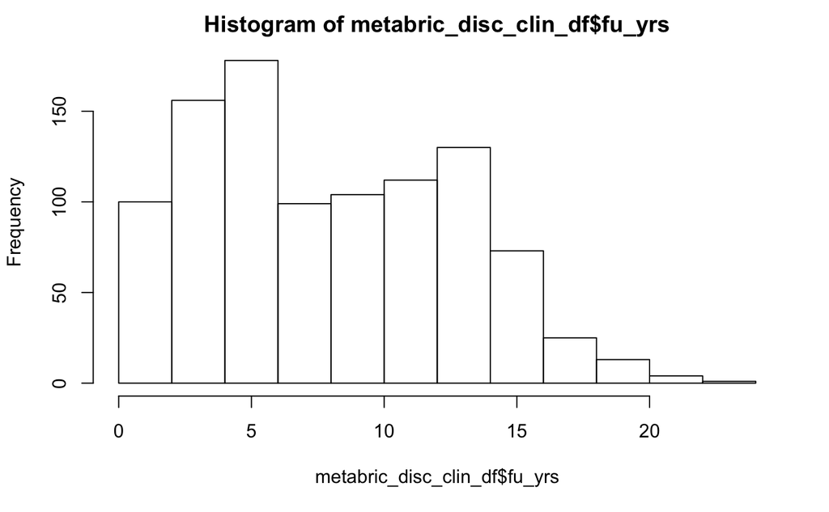

```r
metabric_disc_clin_df$fu_yrs = metabric_disc_clin_df$T/365
hist(metabric_disc_clin_df$fu_yrs)
```

We’ll use a different variable, `OS_Status`, that indicates the “overall survival” status at the last followup time. This is typically coded as ‘1’ for dead and ‘0’ for alive. And it can be for any reason, not just death due to cancer. On the one hand, this includes someone who was run over by a car, but in practice definitively saying that someone died because of their cancer is hard.

```r
table(metabric_disc_clin_df$OS_Status, metabric_disc_clin_df$last_follow_up_status)
```

```
      a   d d-d.s. d-o.c.
  0 548   0      0      0
  1   0  46    259    126
```

Finally, R uses something called a survival variable which conveniently puts that status and time in one place. You can see that it is a vector with the time, and a ‘+’ attached if the person was censored (alive) at that time

```r
metabric_disc_clin_df$surv = Surv(
  metabric_disc_clin_df$T / 365 * 12,
  metabric_disc_clin_df$OS_Status
)
metabric_disc_clin_df$surv
```

```
  [1]  46.3890411   20.1534247   67.3972603+  14.0383562+  43.2328767   16.4054795+  40.3397260+  77.0630137+  71.6383562+
 [10]  60.0986301+   8.9424658  107.7369863+  26.9260274+  54.4109589+  56.0219178+  64.6356164+  44.4164384   63.7150685+
 [19]  80.2191781   55.1671233+  72.0328767+  61.0520548+  58.9808219+  55.1671233+   8.1205479+  62.9917808  119.2767123+
 [28]  18.4109589   60.7232877+  44.8767123   53.5890411   54.8054795+  74.7287671+  23.9013699   65.9506849+ 110.6958904+
 [37]  55.4958904   25.8739726+  14.8931507+  12.7232877+   8.9753425+  48.7561644   49.8410959   58.8493151+  25.9068493
 [46]   5.5561644+  27.0904110   24.0000000   48.1972603+  42.5424658   46.1917808+  51.8465753+  58.2575342   64.6684932+
 [55] 202.7506849   16.0767123+   5.3589041+  63.0575342+  31.9232877+   8.4493151+  61.9068493    1.4136986+  10.2904110+
 [64]  58.2575342+  50.7287671+ 149.9835616   35.4739726+  10.6849315+  60.5260274+  84.8219178+  64.3726027+  59.8684932+
 [73]  43.8246575+  58.6849315   48.7232877+ 120.3287671   50.1369863+  36.1315068   42.3780822   61.1178082+  75.0575342+
 [82]  57.9616438   51.8465753+  46.1260274   88.6684932   54.1479452+  53.8191781+  63.9452055+  28.1753425   19.9232877
 [91]  76.8657534+  88.9972603   30.5753425   35.9342466    0.2630137  270.2465753+   8.3835616+  54.4109589+ 108.3287671
[100]  42.4438356+ 127.3643836+  58.6520548+  60.4273973+  42.1808219+  46.1917808   32.5150685   60.0986301+  45.5342466+
[109]  60.7561644+  52.0767123+  77.6876712+  62.7945205+  54.6410959+  77.0630137+  71.2109589+  78.8383562+  38.6301370
[118]  54.4438356   34.7506849+  28.9315068   77.3260274+ 121.2164384+  66.9698630+  50.1041096+  68.4164384+  56.8438356+
[127]  11.7698630   60.5260274+  66.3780822+  33.3369863   73.1835616+ 149.5890411   54.2794521+  85.3479452+  90.4767123
```

[output cut: 96 more lines]

R uses the `coxph()` function to model censored outcome as a function of predictors — in this case, we can model survival as a function of age.

```r
summary(coxph(surv ~ age_at_diagnosis, data = metabric_disc_clin_df))
```

```
Call:
coxph(formula = surv ~ age_at_diagnosis, data = metabric_disc_clin_df)

  n= 979, number of events= 431
   (18 observations deleted due to missingness)

                     coef exp(coef) se(coef)     z Pr(>|z|)
age_at_diagnosis 0.024800  1.025110 0.004129 6.006  1.9e-09 ***
---
Signif. codes:  0 ‘***’ 0.001 ‘**’ 0.01 ‘*’ 0.05 ‘.’ 0.1 ‘ ’ 1

                 exp(coef) exp(-coef) lower .95 upper .95
age_at_diagnosis     1.025     0.9755     1.017     1.033

Concordance= 0.562  (se = 0.015 )
Rsquare= 0.037   (max possible= 0.996 )
Likelihood ratio test= 37.18  on 1 df,   p=1.079e-09
Wald test            = 36.07  on 1 df,   p=1.904e-09
Score (logrank) test = 36.4  on 1 df,   p=1.609e-09
```

In the above, each increase of age by 1 year is associated with 1.03-fold increase in risk of death

Breast cancer was one of the first cancers to be split into groups based on gene expression pattern. These are called intrinsic types, or PAM50 groups. Since this splits patients into groups we can generate the Kaplan Meier plot. Note, we can limit the analysis to patients who are <70 years old to isolate part of the effect that older patients are likely to die sooner anyway.

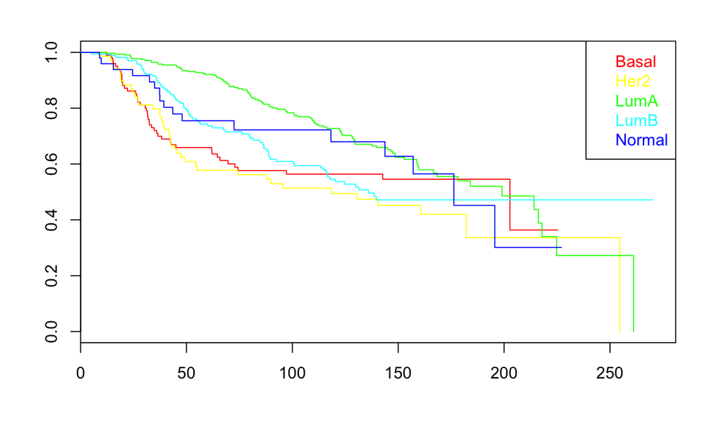

```r
byPam50 <- table(metabric_disc_clin_df$Pam50Subtype)
plot(survfit(surv ~ Pam50Subtype, data = metabric_disc_clin_df,
             subset = age_at_diagnosis < 70), col = rainbow(6))
legend("topright", names(byPam50), text.col = rainbow(6))
```

Back to AURKA — how strongly is it associated with outcome and in which direction?

```r
coxph(metabric_disc_clin_df$surv ~ aurka)
```

```
Call:
coxph(formula = metabric_disc_clin_df$surv ~ aurka)

        coef exp(coef) se(coef)    z       p
aurka 0.2195    1.2455   0.0544 4.03 5.5e-05

Likelihood ratio test=15.7  on 1 df, p=7.46e-05
n= 979, number of events= 431
   (18 observations deleted due to missingness)
```

We can define groups of patients according to whether they have “high” or “low” expression of AURKA by whether their’s is higher or lower than the median.

```r
median(aurka)
```

```
[1] 7.599
```

```r
aurka_hi <- rep(FALSE, length(aurka))
aurka_hi[aurka > median(aurka)] <- TRUE
aurka[1:10]
```

```
 [1] 7.918 9.626 7.689 7.738 8.612 7.083 6.769 8.211 9.697 8.645
```

```r
aurka_hi[1:10]
```

```
 [1]  TRUE  TRUE  TRUE  TRUE  TRUE FALSE FALSE  TRUE  TRUE  TRUE
```

Then we can fit a coxph model to this split, and also examine the Kaplan Meier.

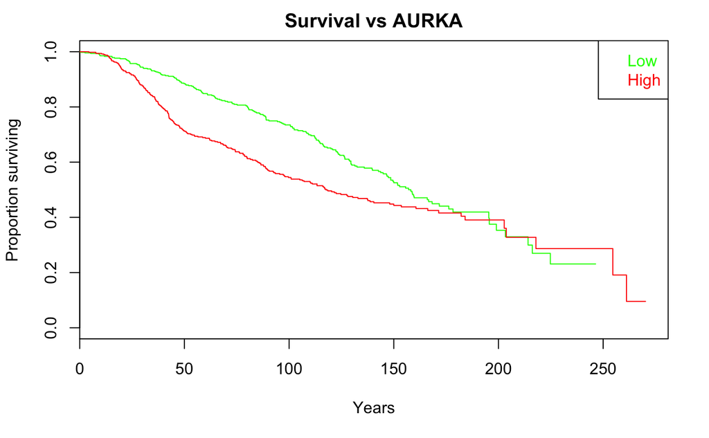

```r
plot(survfit(metabric_disc_clin_df$surv ~ aurka_hi),
     col = c("green", "red"), xlab = "Years", ylab = "Proportion surviving",
     main="Survival vs AURKA")
legend("topright", c("Low","High"), text.col = c("green", "red"))
```

```r
coxph(metabric_disc_clin_df$surv ~ aurka_hi)
```

```
Call:
coxph(formula = metabric_disc_clin_df$surv ~ aurka_hi)

               coef exp(coef) se(coef)    z       p
aurka_hiTRUE 0.3629    1.4375   0.0972 3.73 0.00019

Likelihood ratio test=14  on 1 df, p=0.000179
n= 979, number of events= 431
   (18 observations deleted due to missingness)
```

That’s it! In principal you could now write a function that makes a table of the relationship of all genes to overall survival, and select one or more that are most prognostic.